# Regression

Sarah Zirkle

November 9, 2021

# 1 Dataset

For this assignment I will be using the dataset provided in class but for a different state - Kentucky.

```r
data <- read.csv('./Data/childpov18_southfull.csv',
                 colClasses = c("character", "character", "character",
                                "numeric", "numeric", "numeric", "numeric",
                                "numeric", "numeric", "numeric", "numeric",
                                "numeric", "numeric", "numeric", "numeric",
                                "numeric", "numeric", "numeric", "numeric",
                                "numeric", "numeric", "numeric", "numeric",
                                "numeric", "numeric", "numeric", "numeric",
                                "numeric", "numeric", "numeric", "numeric",
                                "numeric", "numeric", "numeric", "numeric"))
```

I subset KY out of all of the states since we are going to be looking at this specific state!

Kentucky was ranked 29th out of 50 states in the 2021 edition of Rich States, Poor States.

```r
ky_pov <- data %>% subset(State == "KY")
```

```r
summary(ky_pov)
```

```
##      FIPS              State           County_Name          Longitude
##  Length:120         Length:120         Length:120         Min.   :-89.17
##  Class :character   Class :character   Class :character   1st Qu.:-86.27
##  Mode  :character   Mode  :character   Mode  :character   Median :-84.88
##                                                           Mean   :-85.21
##                                                           3rd Qu.:-83.91
##                                                           Max.   :-82.39
##     Latitude     child.pov.2016  unemployment_13    per_lhs_13
##  Min.   :36.55   Min.   : 8.20   Min.   : 5.300   Min.   : 8.10
##  1st Qu.:37.11   1st Qu.:23.50   1st Qu.: 7.500   1st Qu.:15.82
##  Median :37.58   Median :28.30   Median : 8.800   Median :21.00
##  Mean   :37.62   Mean   :29.93   Mean   : 9.448   Mean   :21.60
##  3rd Qu.:38.05   3rd Qu.:35.25   3rd Qu.:10.700   3rd Qu.:26.55
##  Max.   :38.97   Max.   :55.30   Max.   :18.200   Max.   :38.60
##   per_black_13     per_hispanic_13   per_ag_13       per_construction_13
##  Min.   : 0.0000   Min.   :0.000   Min.   : 0.2723   Min.   : 2.460
##  1st Qu.: 0.7448   1st Qu.:0.971   1st Qu.: 2.3941   1st Qu.: 5.892
##  Median : 2.4523   Median :1.636   Median : 4.0026   Median : 6.977
##  Mean   : 3.6308   Mean   :2.097   Mean   : 5.4491   Mean   : 7.356
##  3rd Qu.: 4.9281   3rd Qu.:2.725   3rd Qu.: 6.9995   3rd Qu.: 8.363
##  Max.   :23.2782   Max.   :8.981   Max.   :29.8089   Max.   :13.095
##  per_manufacturing_13 per_retail_13    per_healthss_13 per_singlemom_13
##  Min.   : 1.792       Min.   : 5.202   Min.   :15.31   Min.   : 4.447
##  1st Qu.:12.034       1st Qu.:10.378   1st Qu.:20.46   1st Qu.: 8.165
##  Median :16.223       Median :11.723   Median :23.38   Median : 9.905
##  Mean   :16.031       Mean   :11.703   Mean   :23.65   Mean   : 9.720
##  3rd Qu.:21.080       3rd Qu.:13.432   3rd Qu.:25.69   3rd Qu.:11.173
##  Max.   :36.762       Max.   :16.477   Max.   :34.81   Max.   :16.658
##      urban            rural       lnchildpov    lnunemployment     lnlesshs
##  Min.   :0.0000   Min.   :0.0   Min.   :2.104   Min.   :1.668   Min.   :2.092
##  1st Qu.:0.0000   1st Qu.:0.0   1st Qu.:3.157   1st Qu.:2.015   1st Qu.:2.762
##  Median :0.0000   Median :0.0   Median :3.343   Median :2.175   Median :3.045
##  Mean   :0.2917   Mean   :0.3   Mean   :3.341   Mean   :2.210   Mean   :3.018
##  3rd Qu.:1.0000   3rd Qu.:1.0   3rd Qu.:3.562   3rd Qu.:2.370   3rd Qu.:3.279
##  Max.   :1.0000   Max.   :1.0   Max.   :4.013   Max.   :2.901   Max.   :3.653
##     lnblack          lnhispanic           lnag         lnconstruction
##  Min.   :-4.8992   Min.   :-4.6052   Min.   :-1.3010   Min.   :0.9002
##  1st Qu.:-0.2946   1st Qu.:-0.0296   1st Qu.: 0.8729   1st Qu.:1.7737
##  Median : 0.8970   Median : 0.4919   Median : 1.3869   Median :1.9426
##  Mean   : 0.5875   Mean   : 0.3708   Mean   : 1.3684   Mean   :1.9572
```

[output cut: 8 more lines]

```
##  Max.   :3.6045   Max.   :2.802   Max.   :3.550   Max.   :2.813
##    lnchpov17      lnuninsured    lnincome_ratio  lnsevere_housing
##  Min.   :1.974   Min.   :2.266   Min.   :1.162   Min.   :1.921
##  1st Qu.:3.105   1st Qu.:2.793   1st Qu.:1.478   1st Qu.:2.494
##  Median :3.321   Median :2.866   Median :1.590   Median :2.598
##  Mean   :3.301   Mean   :2.853   Mean   :1.580   Mean   :2.584
##  3rd Qu.:3.548   3rd Qu.:2.942   3rd Qu.:1.681   3rd Qu.:2.701
##  Max.   :4.022   Max.   :3.115   Max.   :1.894   Max.   :3.089
##   lnteenbirth     lnunmarried
##  Min.   :2.740   Min.   :0.010
##  1st Qu.:3.799   1st Qu.:3.018
##  Median :4.004   Median :3.431
##  Mean   :3.956   Mean   :3.214
##  3rd Qu.:4.158   3rd Qu.:3.688
##  Max.   :4.489   Max.   :4.459
```

# 2 Ordinary Least Squares

I made an equation as an object and ran a simple OLS regression.

```r
equation <- child.pov.2016 ~ rural + urban + lnmanufacturing + lnag +
            lnretail + lnhealthss + lnconstruction + lnlesshs +
            lnunemployment + lnsinglemom + lnblack + lnhispanic +
            lnuninsured + lnincome_ratio + lnteenbirth + lnunmarried
```

I set my scientific notation to 5 decimal points.

```r
options(scipen = 5)
```

```r
ols <- lm(equation, data=ky_pov)
summary(ols)
```

```
##
## Call:
## lm(formula = equation, data = ky_pov)
##
## Residuals:
##      Min       1Q   Median       3Q      Max
## -15.7203  -4.0479   0.0278   3.8008  15.5434
##
## Coefficients:
##                 Estimate Std. Error t value Pr(>|t|)
## (Intercept)     -83.4140    24.8136  -3.362  0.00109 **
## rural             0.9198     1.5843   0.581  0.56280
## urban             1.1785     1.6835   0.700  0.48548
## lnmanufacturing   1.6995     1.5728   1.081  0.28242
## lnag             -0.4139     0.9537  -0.434  0.66518
## lnretail         -1.7800     3.3587  -0.530  0.59729
## lnhealthss        3.7004     4.7166   0.785  0.43452
## lnconstruction    0.9644     2.4640   0.391  0.69632
## lnlesshs         10.7766     4.3340   2.487  0.01451 *
## lnunemployment   11.7755     4.2236   2.788  0.00632 **
## lnsinglemom       1.3482     2.5920   0.520  0.60409
## lnblack           0.3994     0.5298   0.754  0.45265
## lnhispanic       -0.4861     0.7680  -0.633  0.52814
## lnuninsured       0.4240     7.7298   0.055  0.95636
## lnincome_ratio   18.4578     5.8659   3.147  0.00216 **
## lnteenbirth       1.3717     1.9576   0.701  0.48508
## lnunmarried       0.6695     0.6754   0.991  0.32385
## ---
## Signif. codes:  0 '***' 0.001 '**' 0.01 '*' 0.05 '.' 0.1 ' ' 1
##
## Residual standard error: 6.066 on 103 degrees of freedom
## Multiple R-squared:  0.6697, Adjusted R-squared:  0.6184
## F-statistic: 13.06 on 16 and 103 DF,  p-value: < 2.2e-16
```

This model ultimately was significant. My p-value was 2.2e-16.

There are a few significant variables within the model such as: less than high school education, unemployment, and income ratio.

# 3 Spatial Regression Analysis

## 3.1 Contiguity neighbors

In order to determine underlying relationships, I made polygons for each of the counties in Kentucky.

```r
fips <- county.fips
fips.codes <- separate(data = fips, col = polyname, into = c("state", "county"), sep = ",")
ky_fips <- subset(fips.codes, state=="kentucky", select=fips)

kentucky <- map(database = "county", regions = "kentucky", fill=T, plot=F)
ky_sp = map2SpatialPolygons(kentucky,ky_fips$fips,CRS("+proj=longlat"))
```

Next lets clean up our polygons and set up our neighbors!

```r
require(maptools)
sf::sf_use_s2(FALSE)
```

```
## Spherical geometry (s2) switched off
```

```r
 file <- system.file("extdata", "example.shp", package = "cleangeo")
 sp <- readShapePoly(file)

 cleaned <- clgeo_Clean(ky_sp)
 report.clean <- clgeo_CollectionReport(cleaned)
 clgeo_SummaryReport(report.clean)
```

```
##    type      valid         issue_type
##  NA's:120   Mode:logical   NA's:120
##             TRUE:120
```

```r
neighb.data <- poly2nb(cleaned, queen=T)
cont.neighb <- nb2listw(neighb.data,style="W", zero.policy = TRUE)
```

## 3.2 Moran's Correlation and LaGrange Multiplier Tests

Next, I will run Moran's Correlation and LaGrange Multiplier tests.

```r
lm.morantest(ols, cont.neighb)
```

```
##
##  Global Moran I for regression residuals
##
## data:
## model: lm(formula = equation, data = ky_pov)
## weights: cont.neighb
##
## Moran I statistic standard deviate = 0.41073, p-value = 0.3406
## alternative hypothesis: greater
## sample estimates:
## Observed Moran I      Expectation         Variance
##      -0.01094433      -0.03359996       0.00304250
```

The Moran's Correlation Test produced a p-value of 0.3406. This is not significant. Therefore, we would fail to reject the null hypothesis that there is "no detection of spatial dependency in our dataset."

This suggests that the simple OLS is the best model going forward, and there is no reason to run spatial regression analysis.

For practice I will still run the LaGrange Multiplier Test to see what happens.

```r
lm.LMtests(ols, cont.neighb, test="all")
```

```
##
##  Lagrange multiplier diagnostics for spatial dependence
##
## data:
## model: lm(formula = equation, data = ky_pov)
## weights: cont.neighb
##
## LMerr = 0.03413, df = 1, p-value = 0.8534
##
##
##  Lagrange multiplier diagnostics for spatial dependence
##
## data:
## model: lm(formula = equation, data = ky_pov)
## weights: cont.neighb
##
## LMlag = 0.39124, df = 1, p-value = 0.5316
##
##
##  Lagrange multiplier diagnostics for spatial dependence
##
## data:
## model: lm(formula = equation, data = ky_pov)
## weights: cont.neighb
##
## RLMerr = 1.1122, df = 1, p-value = 0.2916
##
##
##  Lagrange multiplier diagnostics for spatial dependence
##
## data:
## model: lm(formula = equation, data = ky_pov)
## weights: cont.neighb
##
## RLMlag = 1.4693, df = 1, p-value = 0.2255
##
##
##  Lagrange multiplier diagnostics for spatial dependence
##
## data:
## model: lm(formula = equation, data = ky_pov)
## weights: cont.neighb
##
## SARMA = 1.5034, df = 2, p-value = 0.4716
```

The results are:

[output not shown]

We will remove SARMA because it is not appropriate for the p-value and the robust models that are used to filter out the false positives in the data.

The best model of all would be the RLMlag model with a p-value of 0.2255 (but not really).

Using the handy dandy decision tree we can follow the path of OLS Regression -> Neither LM-Error nor LM-Lag -> Stop and Keep OLS Results

## 3.3 Spatially Lagged X Model

```r
SLX.model <- spatialreg::lmSLX(equation, data=ky_pov, cont.neighb)
summary(SLX.model)
```

```
##
## Call:
## lm(formula = formula(paste("y ~ ", paste(colnames(x)[-1], collapse = "+"))),
##     data = as.data.frame(x), weights = weights)
##
## Residuals:
##      Min       1Q   Median       3Q      Max
## -12.7251  -3.4924  -0.1933   3.2618  13.0676
##
## Coefficients:
##                      Estimate Std. Error t value Pr(>|t|)
## (Intercept)         -108.9234    66.7085  -1.633   0.1061
## rural                  0.7107     1.6394   0.433   0.6657
## urban                  1.2574     1.8162   0.692   0.4906
## lnmanufacturing        5.1466     2.1208   2.427   0.0173 *
## lnag                  -1.9947     1.2849  -1.552   0.1242
## lnretail              -3.1555     3.5271  -0.895   0.3735
## lnhealthss             5.0183     5.3133   0.944   0.3475
## lnconstruction         2.0440     2.5841   0.791   0.4311
## lnlesshs               7.0328     5.0281   1.399   0.1655
## lnunemployment         7.4224     4.6469   1.597   0.1138
## lnsinglemom            1.1470     2.7216   0.421   0.6745
## lnblack                0.5570     0.5499   1.013   0.3139
## lnhispanic            -0.2123     0.8160  -0.260   0.7954
## lnuninsured           10.1726     8.5347   1.192   0.2365
## lnincome_ratio         8.5948     6.2558   1.374   0.1730
## lnteenbirth            0.1579     2.1505   0.073   0.9416
## lnunmarried            0.1784     0.6753   0.264   0.7923
## lag.rural             -1.3006     3.7736  -0.345   0.7312
## lag.urban              0.5609     4.2986   0.130   0.8965
## lag.lnmanufacturing   -3.7064     3.7279  -0.994   0.3229
## lag.lnag               3.7542     2.1684   1.731   0.0869 .
## lag.lnretail           6.2894     7.6591   0.821   0.4138
## lag.lnhealthss        13.6572    11.5491   1.183   0.2402
## lag.lnconstruction    -2.3935     6.2545  -0.383   0.7029
## lag.lnlesshs          24.7583     9.4333   2.625   0.0102 *
## lag.lnunemployment   -18.3147     9.5793  -1.912   0.0592 .
## lag.lnsinglemom        3.3751     6.5791   0.513   0.6092
## lag.lnblack           -2.1399     1.2554  -1.704   0.0919 .
## lag.lnhispanic         1.2299     1.8961   0.649   0.5183
## lag.lnuninsured      -29.9983    21.5098  -1.395   0.1667
## lag.lnincome_ratio    -3.8767    15.3813  -0.252   0.8016
## lag.lnteenbirth        7.2147     4.9991   1.443   0.1526
## lag.lnunmarried        1.3057     1.5336   0.851   0.3969
## ---
## Signif. codes:  0 '***' 0.001 '**' 0.01 '*' 0.05 '.' 0.1 ' ' 1
##
## Residual standard error: 5.739 on 87 degrees of freedom
## Multiple R-squared:  0.7503, Adjusted R-squared:  0.6585
## F-statistic: 8.171 on 32 and 87 DF,  p-value: 3.175e-15
```

We don't need to perform a SLX model but when we do run it there is a change in what variables impact child poverty in KY in 2016. The model itself is significant. The OLS said that less than high school education, unemployment, and income ratio were the significant variables impacting poverty.

This model is significant with a p-value of 3.175e-15.

```r
summary(spatialreg::impacts(SLX.model, cont.neighb), zstats = TRUE)[["pzmat"]]
```

```
##                     Direct    Indirect        Total
## rural           0.66465299 0.730344819 0.8927894094
## urban           0.48874495 0.896186166 0.6799185326
## lnmanufacturing 0.01523327 0.320107556 0.6669124920
## lnag            0.12054876 0.083392680 0.3377823150
## lnretail        0.37098816 0.411549972 0.6988665253
## lnhealthss      0.34492543 0.236992706 0.1056664293
## lnconstruction  0.42895091 0.701957406 0.9588811131
## lnlesshs        0.16190556 0.008675853 0.0006421135
## lnunemployment  0.11020577 0.055889521 0.3025194796
## lnsinglemom     0.67343486 0.607948790 0.5232215726
## lnblack         0.31109805 0.088289911 0.2531761919
## lnhispanic      0.79474354 0.516561771 0.6476445551
## lnuninsured     0.23329535 0.163126142 0.4133496623
## lnincome_ratio  0.16947590 0.801011138 0.7806935463
## lnteenbirth     0.94147005 0.148962873 0.2089414846
## lnunmarried     0.79166273 0.394524011 0.3647290473
```

## 3.4 Spatial Lag Model

```r
sp.lag.model <- spatialreg::lagsarlm(equation, data=ky_pov, cont.neighb)
summary(sp.lag.model, Nagelkerke = TRUE)
```

```
##
## Call:
## spatialreg::lagsarlm(formula = equation, data = ky_pov, listw = cont.neighb)
##
## Residuals:
##      Min       1Q   Median       3Q      Max
## -15.4695  -4.0843  -0.1548   3.8331  15.2626
##
## Type: lag
## Coefficients: (asymptotic standard errors)
##                  Estimate Std. Error z value  Pr(>|z|)
## (Intercept)     -80.40069   23.49298 -3.4223 0.0006209
## rural             0.93475    1.46374  0.6386 0.5230821
## urban             1.16074    1.55545  0.7462 0.4555237
## lnmanufacturing   1.71326    1.45313  1.1790 0.2383906
## lnag             -0.46131    0.88142 -0.5234 0.6007168
## lnretail         -2.25070    3.13935 -0.7169 0.4734164
## lnhealthss        3.04418    4.43138  0.6870 0.4921085
## lnconstruction    1.12339    2.27719  0.4933 0.6217855
## lnlesshs          9.52276    4.18655  2.2746 0.0229293
## lnunemployment   11.66793    3.93321  2.9665 0.0030119
## lnsinglemom       1.14048    2.40424  0.4744 0.6352417
## lnblack           0.46678    0.49206  0.9486 0.3428144
## lnhispanic       -0.46606    0.71005 -0.6564 0.5115848
## lnuninsured       1.41433    7.16111  0.1975 0.8434348
## lnincome_ratio   18.09881    5.43658  3.3291 0.0008713
## lnteenbirth       1.24399    1.81275  0.6862 0.4925579
## lnunmarried       0.69269    0.62520  1.1080 0.2678807
##
## Rho: 0.084812, LR test value: 0.4903, p-value: 0.48379
## Asymptotic standard error: 0.1068
##     z-value: 0.79413, p-value: 0.42712
## Wald statistic: 0.63064, p-value: 0.42712
##
## Log likelihood: -377.1925 for lag model
## ML residual variance (sigma squared): 31.412, (sigma: 5.6046)
## Nagelkerke pseudo-R-squared: 0.67109
## Number of observations: 120
## Number of parameters estimated: 19
## AIC: 792.39, (AIC for lm: 790.88)
## LM test for residual autocorrelation
## test value: 0.68283, p-value: 0.40861
```

```r
summary(spatialreg::impacts(sp.lag.model, listw = cont.neighb, R=100), zstats = TRUE)[["pzmat"]]
```

```
##                      Direct  Indirect       Total
## rural           0.434731434 0.6250332 0.437664443
## urban           0.413997436 0.6303476 0.415624463
## lnmanufacturing 0.222269458 0.6123879 0.241126969
## lnag            0.543089959 0.7413538 0.542297235
## lnretail        0.449186396 0.6490574 0.459805146
## lnhealthss      0.479750396 0.8550294 0.503881387
## lnconstruction  0.592606907 0.7699098 0.596666765
## lnlesshs        0.014886424 0.5361203 0.008832810
## lnunemployment  0.002738107 0.4895443 0.004101357
## lnsinglemom     0.588044452 0.8231232 0.597171666
## lnblack         0.228933662 0.5814709 0.255094211
## lnhispanic      0.526696526 0.7117482 0.526380724
## lnuninsured     0.933468865 0.8601104 0.918123382
## lnincome_ratio  0.003395742 0.5058817 0.005458854
## lnteenbirth     0.337056350 0.5807860 0.326423269
## lnunmarried     0.231505943 0.5724161 0.254283928
```

## 3.5 Spatial Error Model

```r
sp.err.model <- spatialreg::errorsarlm(equation, data=ky_pov, cont.neighb)
summary(sp.err.model, Nagelkerke = TRUE)
```

```
##
## Call:
## spatialreg::errorsarlm(formula = equation, data = ky_pov, listw = cont.neighb)
##
## Residuals:
##       Min        1Q    Median        3Q       Max
## -15.62876  -4.09642   0.16359   3.80167  15.55423
##
## Type: error
## Coefficients: (asymptotic standard errors)
##                  Estimate Std. Error z value  Pr(>|z|)
## (Intercept)     -82.88558   22.75693 -3.6422 0.0002703
## rural             0.90681    1.46946  0.6171 0.5371660
## urban             1.22842    1.55279  0.7911 0.4288829
## lnmanufacturing   1.69413    1.44040  1.1762 0.2395318
## lnag             -0.35628    0.87081 -0.4091 0.6824394
## lnretail         -1.69752    3.10086 -0.5474 0.5840802
## lnhealthss        3.77508    4.33788  0.8703 0.3841592
## lnconstruction    0.87070    2.27895  0.3821 0.7024145
## lnlesshs         11.09785    3.98562  2.7845 0.0053614
## lnunemployment   11.48613    3.90426  2.9419 0.0032616
## lnsinglemom       1.38747    2.39493  0.5793 0.5623616
## lnblack           0.37388    0.48985  0.7632 0.4453152
## lnhispanic       -0.48364    0.71236 -0.6789 0.4971872
## lnuninsured      -0.13624    7.15865 -0.0190 0.9848160
## lnincome_ratio   18.51422    5.41332  3.4201 0.0006259
## lnteenbirth       1.42599    1.81562  0.7854 0.4322185
## lnunmarried       0.67973    0.62425  1.0889 0.2762032
##
## Lambda: -0.042509, LR test value: 0.055733, p-value: 0.81337
## Asymptotic standard error: 0.14238
##     z-value: -0.29855, p-value: 0.76528
## Wald statistic: 0.089135, p-value: 0.76528
##
## Log likelihood: -377.4098 for error model
## ML residual variance (sigma squared): 31.561, (sigma: 5.6179)
## Nagelkerke pseudo-R-squared: 0.6699
## Number of observations: 120
## Number of parameters estimated: 19
## AIC: 792.82, (AIC for lm: 790.88)
```

With the spatial error model, we get the same significant variables as the OLS: less than high school education, unemployment and income ratio. This model is not significant with a p-value of 0.81337 and a pseudo-R-squared of 0.6699.

```r
spatialreg::Hausman.test(sp.err.model)
```

```
##
##  Spatial Hausman test (asymptotic)
##
## data:  NULL
## Hausman test = 9.3057, df = 17, p-value = 0.9302
```

If the p-value had been significant, we would have concluded that the use of OLS or a standard error model may not be appropriate for this set of variables (but we know it is).

```r
sd.err <- spatialreg::errorsarlm(equation, ky_pov, cont.neighb, etype = "emixed")
sdm <- spatialreg::lagsarlm(equation, ky_pov, cont.neighb, type = "mixed")
```

```r
summary(sd.err, Nagelkerke = TRUE)
```

```
##
## Call:
## spatialreg::errorsarlm(formula = equation, data = ky_pov, listw = cont.neighb,
##     etype = "emixed")
##
## Residuals:
##       Min        1Q    Median        3Q       Max
## -12.32077  -3.51834  -0.42089   3.16220  12.77331
##
## Type: error
## Coefficients: (asymptotic standard errors)
##                       Estimate Std. Error z value  Pr(>|z|)
## (Intercept)         -88.594604  52.569485 -1.6853 0.0919335
## rural                 0.799315   1.376662  0.5806 0.5614976
## urban                 1.129839   1.556793  0.7257 0.4679933
## lnmanufacturing       5.186851   1.843177  2.8141 0.0048917
## lnag                 -2.105545   1.132484 -1.8592 0.0629949
## lnretail             -2.346848   3.025430 -0.7757 0.4379219
## lnhealthss            5.204814   4.617279  1.1272 0.2596381
## lnconstruction        2.146533   2.194357  0.9782 0.3279726
## lnlesshs              7.338464   4.383692  1.6740 0.0941233
## lnunemployment        7.759269   3.976707  1.9512 0.0510357
## lnsinglemom           0.929299   2.334011  0.3982 0.6905157
## lnblack               0.551343   0.469904  1.1733 0.2406712
## lnhispanic           -0.222891   0.687421 -0.3242 0.7457547
## lnuninsured          10.076262   7.170660  1.4052 0.1599598
## lnincome_ratio        9.392007   5.329437  1.7623 0.0780205
## lnteenbirth          -0.049539   1.788050 -0.0277 0.9778972
## lnunmarried           0.098359   0.578042  0.1702 0.8648848
## lag.rural            -1.160658   3.011949 -0.3854 0.6999773
## lag.urban            -0.311715   3.460258 -0.0901 0.9282201
## lag.lnmanufacturing  -3.519633   3.042329 -1.1569 0.2473183
## lag.lnag              3.689064   1.830205  2.0157 0.0438360
## lag.lnretail          4.983371   6.116790  0.8147 0.4152420
## lag.lnhealthss       14.691845   9.643205  1.5235 0.1276227
## lag.lnconstruction   -3.702221   5.030636 -0.7359 0.4617703
## lag.lnlesshs         25.975170   7.664947  3.3888 0.0007019
## lag.lnunemployment  -20.786634   7.732889 -2.6881 0.0071864
## lag.lnsinglemom       2.486739   5.299066  0.4693 0.6388704
## lag.lnblack          -2.069028   0.984668 -2.1012 0.0356196
## lag.lnhispanic        1.224766   1.495820  0.8188 0.4129048
## lag.lnuninsured     -36.188406  17.467449 -2.0718 0.0382876
## lag.lnincome_ratio   -2.720007  12.368989 -0.2199 0.8259449
## lag.lnteenbirth       6.402555   4.078343  1.5699 0.1164404
## lag.lnunmarried       1.610010   1.226331  1.3129 0.1892278
##
## Lambda: -0.25738, LR test value: 2.2268, p-value: 0.13563
## Asymptotic standard error: 0.14742
##     z-value: -1.7459, p-value: 0.080826
## Wald statistic: 3.0482, p-value: 0.080826
##
## Log likelihood: -359.5371 for error model
## ML residual variance (sigma squared): 23.139, (sigma: 4.8103)
## Nagelkerke pseudo-R-squared: 0.75494
## Number of observations: 120
## Number of parameters estimated: 35
## AIC: 789.07, (AIC for lm: 789.3)
```

```r
summary(spatialreg::impacts(sd.err, listw = cont.neighb, R = 100), zstats = TRUE)[["pzmat"]]
```

```
##                      Direct     Indirect         Total
## rural           0.561497647 0.6999772725 0.91283452006
## urban           0.467993293 0.9282200969 0.80630832323
## lnmanufacturing 0.004891663 0.2473183042 0.50358287942
## lnag            0.062994942 0.0438360177 0.24774698782
## lnretail        0.437921909 0.4152419974 0.66249895991
## lnhealthss      0.259638085 0.1276227102 0.02564571788
## lnconstruction  0.327972619 0.4617702587 0.76052182164
## lnlesshs        0.094123256 0.0007019257 0.00000126374
## lnunemployment  0.051035669 0.0071863888 0.10070155398
## lnsinglemom     0.690515733 0.6388703875 0.52406535260
## lnblack         0.240671186 0.0356195751 0.13698499279
## lnhispanic      0.745754663 0.4129047823 0.54734751962
## lnuninsured     0.159959760 0.0382875947 0.16154133223
## lnincome_ratio  0.078020535 0.8259448613 0.60737121709
## lnteenbirth     0.977897154 0.1164404060 0.16060505480
## lnunmarried     0.864884760 0.1892277943 0.16109330259
```

The model was not significant with a p-value of 0.13563.

```r
LR.Sarlm(sd.err,sp.err.model)
```

```
##
##  Likelihood ratio for spatial linear models
##
## data:
## Likelihood ratio = 35.745, df = 16, p-value = 0.003138
## sample estimates:
##       Log likelihood of sd.err Log likelihood of sp.err.model
##                      -359.5371                      -377.4098
```

To provide further evidence of that, the p-value for the comparison of the SLX model is 3.175e-15 and 2.2e-16. Furthermore, this shows that we should restrict the models to either the spatial error model or the OLS.

# 4 Spatial Regression Analysis, K nearest neighbors

OK... now for the brain explosion.

```r
all.xy <-centroid(ky_sp)
colnames(all.xy) <- c("x","y")
```

```r
#Create neighbors
all.dist.k1 <- knn2nb(knearneigh(all.xy, k=1, longlat = TRUE))
all.dist.k3 <- knn2nb(knearneigh(all.xy, k=3, longlat = TRUE))
all.dist.k5 <- knn2nb(knearneigh(all.xy, k=5, longlat = TRUE))

#Determine max k distance value to neighbor
all.max.k1 <- max(unlist(nbdists(all.dist.k1, all.xy, longlat=TRUE)))
all.max.k3 <- max(unlist(nbdists(all.dist.k3, all.xy, longlat=TRUE)))
all.max.k5 <- max(unlist(nbdists(all.dist.k5, all.xy, longlat=TRUE)))

#Calculate neighbors based on distance
all.sp.dist.k1 <- dnearneigh(all.xy, d1=0, d2=1 * all.max.k1, longlat = TRUE)
all.sp.dist.k3 <- dnearneigh(all.xy, d1=0, d2=1 * all.max.k3, longlat = TRUE)
all.sp.dist.k5 <- dnearneigh(all.xy, d1=0, d2=1 * all.max.k5, longlat = TRUE)

#Create neighbor list
all.dist.neighb.k1 <- nb2listw(all.sp.dist.k1,style="W", zero.policy = TRUE)
all.dist.neighb.k3 <- nb2listw(all.sp.dist.k3,style="W", zero.policy = TRUE)
all.dist.neighb.k5 <- nb2listw(all.sp.dist.k5,style="W", zero.policy = TRUE)
```

## 4.1 Distance Lag Model

```r
all.dist.lag.k1 <- spatialreg::lagsarlm(equation, data = ky_pov, listw = all.dist.neighb.k1)
all.dist.lag.k3 <- spatialreg::lagsarlm(equation, data = ky_pov, listw = all.dist.neighb.k3)
all.dist.lag.k5 <- spatialreg::lagsarlm(equation, data = ky_pov, listw = all.dist.neighb.k5)
```

```r
summary(all.dist.lag.k1, Nagelkerke = TRUE)
```

```
##
## Call:
## spatialreg::lagsarlm(formula = equation, data = ky_pov, listw = all.dist.neighb.k1)
##
## Residuals:
##        Min         1Q     Median         3Q        Max
## -15.457997  -4.153543  -0.083926   3.816454  15.006869
##
## Type: lag
## Coefficients: (asymptotic standard errors)
##                  Estimate Std. Error z value  Pr(>|z|)
## (Intercept)     -78.65355   23.33174 -3.3711 0.0007487
## rural             0.88094    1.45763  0.6044 0.5456037
## urban             1.16164    1.54898  0.7499 0.4532929
## lnmanufacturing   1.66827    1.44691  1.1530 0.2489153
## lnag             -0.48295    0.87732 -0.5505 0.5819851
## lnretail         -2.65239    3.12541 -0.8487 0.3960736
## lnhealthss        2.86289    4.36457  0.6559 0.5118639
## lnconstruction    1.16689    2.26653  0.5148 0.6066689
## lnlesshs          8.97862    4.07179  2.2051 0.0274485
## lnunemployment   11.45413    3.96639  2.8878 0.0038795
## lnsinglemom       0.91082    2.39238  0.3807 0.7034128
## lnblack           0.47509    0.48906  0.9714 0.3313298
## lnhispanic       -0.43046    0.70698 -0.6089 0.5426105
## lnuninsured       1.95504    7.11445  0.2748 0.7834712
## lnincome_ratio   18.15522    5.40303  3.3602 0.0007789
## lnteenbirth       1.21398    1.80734  0.6717 0.5017768
## lnunmarried       0.69772    0.62144  1.1227 0.2615479
##
## Rho: 0.11757, LR test value: 1.2808, p-value: 0.25775
## Asymptotic standard error: 0.092574
##     z-value: 1.27, p-value: 0.20409
## Wald statistic: 1.6129, p-value: 0.20409
##
## Log likelihood: -376.7973 for lag model
## ML residual variance (sigma squared): 31.132, (sigma: 5.5796)
## Nagelkerke pseudo-R-squared: 0.67325
## Number of observations: 120
## Number of parameters estimated: 19
## AIC: 791.59, (AIC for lm: 790.88)
## LM test for residual autocorrelation
## test value: 0.34248, p-value: 0.5584
```

This model is not significant with a p-value of 0.25775. There are significant log variables: unemployed, less than a high school education, and income ratio.

## 4.2 K-distance Error Model

```r
all.dist.err.k1 <- spatialreg::errorsarlm(equation, data = ky_pov, listw = all.dist.neighb.k1)
all.dist.err.k3 <- spatialreg::errorsarlm(equation, data = ky_pov, listw = all.dist.neighb.k3)
all.dist.err.k5 <- spatialreg::errorsarlm(equation, data = ky_pov, listw = all.dist.neighb.k5)
```

```r
summary(all.dist.err.k1, Nagelkerke = TRUE)
```

```
##
## Call:
## spatialreg::errorsarlm(formula = equation, data = ky_pov, listw = all.dist.neighb.k1)
##
## Residuals:
##        Min         1Q     Median         3Q        Max
## -15.948603  -3.962550  -0.015963   3.898860  15.488217
##
## Type: error
## Coefficients: (asymptotic standard errors)
##                  Estimate Std. Error z value  Pr(>|z|)
## (Intercept)     -83.98480   23.23000 -3.6154 0.0002999
## rural             0.90327    1.46221  0.6177 0.5367421
## urban             1.09176    1.56704  0.6967 0.4859871
## lnmanufacturing   1.69864    1.47670  1.1503 0.2500223
## lnag             -0.46951    0.89795 -0.5229 0.6010671
## lnretail         -1.97428    3.11628 -0.6335 0.5263823
## lnhealthss        3.57137    4.39188  0.8132 0.4161172
## lnconstruction    1.10053    2.28769  0.4811 0.6304713
## lnlesshs         10.23419    4.04215  2.5319 0.0113457
## lnunemployment   12.19539    3.91085  3.1183 0.0018187
## lnsinglemom       1.20943    2.40787  0.5023 0.6154685
## lnblack           0.41750    0.49194  0.8487 0.3960592
## lnhispanic       -0.47932    0.70965 -0.6754 0.4993980
## lnuninsured       1.23549    7.15397  0.1727 0.8628875
## lnincome_ratio   18.43354    5.45621  3.3785 0.0007290
## lnteenbirth       1.37981    1.81017  0.7623 0.4459086
## lnunmarried       0.66914    0.62848  1.0647 0.2870208
##
## Lambda: 0.049892, LR test value: 0.13417, p-value: 0.71415
## Asymptotic standard error: 0.11669
##     z-value: 0.42757, p-value: 0.66897
## Wald statistic: 0.18281, p-value: 0.66897
##
## Log likelihood: -377.3706 for error model
## ML residual variance (sigma squared): 31.53, (sigma: 5.6152)
## Nagelkerke pseudo-R-squared: 0.67012
## Number of observations: 120
## Number of parameters estimated: 19
## AIC: 792.74, (AIC for lm: 790.88)
```

This model is not significant with a p-value of 0.714. There are significant log variables: unemployed, less than a high school education, and income ratio (once again - the same as the other models ran).

| R2 | Lag | AIC | R2 | Err | AIC |
| --- | --- | --- | --- | --- | --- |
| 0.67325 | 0.25775 | 791.59 | 0.67012 | 0.71415 | 792.74 |

Meaning..... neither really works for our data.

# 5 Mapping Results

```r
dist.err.data <- summary(all.dist.err.k1, correlation=TRUE, Nagelkerke = TRUE)

dist.err.output <- cbind.data.frame(ky_pov$FIPS,
                                    dist.err.data$fitted.values,
                                    dist.err.data$residual,
                                    ky_pov$child.pov.2016,
                                    ky_pov$lnunemployment,
                                    ky_pov$lnuninsured,
                                    ky_pov$lnlesshs,
                                    ky_pov$lnincome_ratio,
                                    stringsAsFactors = FALSE)

#Renaming columns
colnames(dist.err.output) <- c("fips","fitted","resid","childpov",
                        "unemployed","uninsured","less_hs","income_ratio")
```

```r
ky_fortify <- fortify(ky_sp)

ky_poly <- merge(x = ky_fortify, y = dist.err.output,
                 by.x = "id", by.y = "fips", all = TRUE)

bivariate_data <- bi_class(ky_poly, x = childpov, y = less_hs,
                           dim = 3, style = "quantile", keep_factors = FALSE)

legend <- bi_legend(pal = "GrPink",
                    dim = 3,
                    xlab = "Child Poverty",
                    ylab = "Less than a HS Degree",
                    size = 6)
```

```r
world <- map_data("world")
states <- map_data("state")
southern_states <- subset(states, region %in%
                            c("texas", "arkansas", "louisiana", "mississippi",
                              "alabama", "georgia", "florida", "north carolina",
                              "south carolina", "tennessee", "oklahoma",
                              "kentucky", "west virginia", "virginia",
                              "maryland", "delaware", "district of columbia"))
```

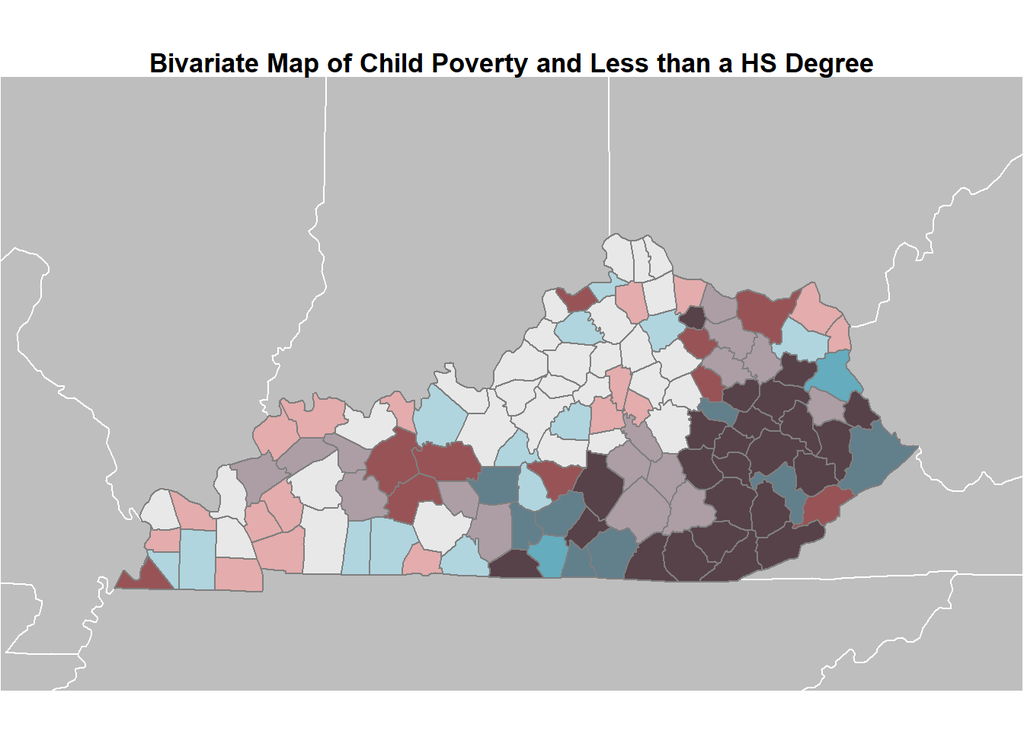

```r
mom_pov_map <- ggplot() +
  geom_polygon(data = world, aes(x=long,y=lat, group=group), fill = "gray95", color = "white") +
  geom_polygon(data = states, aes(x=long,y=lat, group=group), fill = "gray", color = "white") +
  geom_polygon(data = southern_states, aes(x=long,y=lat, group=group), fill = NA, size = 0.01, color = "white") +
  geom_polygon(data = bivariate_data, aes(x=long, y=lat, group=group, fill = bi_class), color = "grey50", show.legend = FALSE) +
  bi_scale_fill(pal = "GrPink", dim = 3) +
  coord_map("conic", lat0 = 30, xlim=c(-90,-81.5), ylim=c(40,36)) +
  theme_void() + theme(legend.title.align=0.5) +
  theme(panel.background = element_rect(fill = 'deepskyblue'),
        panel.grid.major = element_line(colour = NA)) +
  labs(x = "Longitude", y = "Latitude", fill = "Child Poverty",
       title = "Bivariate Map of Child Poverty and Less than a HS Degree") +
  theme(plot.title = element_text(face = "bold", hjust = 0.5))
mom_pov_map
```

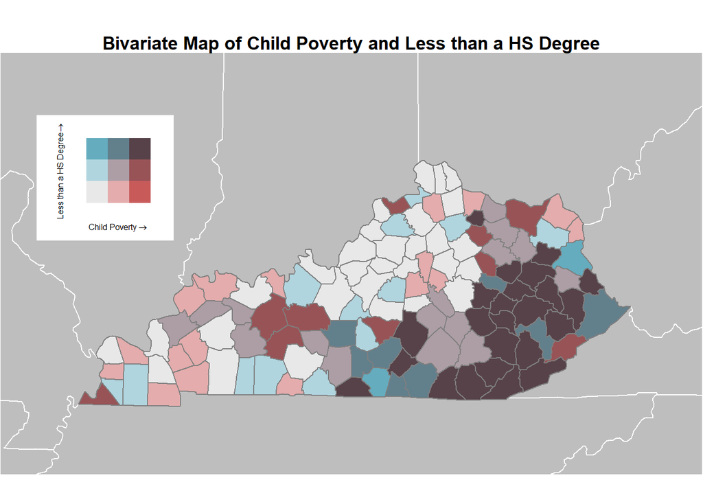

```r
final_map <- ggdraw() +
  draw_plot(mom_pov_map, 0, 0, 1, 1) +
  draw_plot(legend, -0.000077, 0.52, 0.3, 0.25)
final_map
```